# Hw3

Kat Leigh, Alex Milward, David Segan and Mauricio Collado

4/18/2021

### 1. Objective

The objective is to perform a pseudo sensitivity analysis for the squared precipitation coefficient. Then, we calculate the annual net profits for the almond production considering its yield anomaly due to climate variability. We still use the regression model proposed by Lobell et al. (2006):

$$Y(anom)_i = -0.015T_2n,i -0.0046(T_2n,i)^2-0.07p_1,i+0.0043(p_1,i)^2+0.28$$
- Y: yield anomaly in year i (ton/acr).
- Tn: minimum temperature of February in year i (Celsius).
- P: precipitation of January in year i (mm).

For our net profits function (NPV), we consider the sum of the average annual yield and its anomaly (that can be positive or negative), price, costs, used acres, and discount factor.

The **Appendix** has the R source code for:

- Calculating the almond anomaly (assignment 2).
- Computing the annual NPV.
- Computing the almond profits incorporating the sensitivity on squared precipitations.

```r
# import libraries
library(tidyverse)
library(here)
library(devtools)
library(purrr)
library(scales)

# call functions
source("almond_anomaly.R") # almond yield anomaly function
source("almond_profit.R")
source("compute_NPV.R")
```

### 2. Sensitivity analysis

We do the sensitivity on 0.0043P^2 term. We vary it according to a normal distribution 500 times with the mean is equal to the parameter (0.0043), and the standard deviation is 0.001. Then, we graph our results using a boxplot.

```r
# Sensitivity analysis

# read in data
climate_df <- read.delim(here('clim.txt'), sep = " ")

# we create our variables
coef_p2_value <- 0.0043 # set the mean
number_runs <-  500 # set the runs

# we create our variable with a normal distribution
coef_p2 <- rnorm(n=number_runs, mean=coef_p2_value, sd=0.001)

# sensitivity analysis
yield_anomaly_sens = coef_p2 %>%
  map(~almond_anomaly(climate_df, coef_p2=.x)) # we used our runs for coef_p2

head(yield_anomaly_sens)

# we extract the results and then keep them in a dataframe
anom_result = map_df(yield_anomaly_sens,`[`, c("year","yield"))
```

We observe that years with extreme precipitation rates (1995, 2005 and 2008) display outliers for yield anomaly and extreme variability. These results imply doubts about Lobell’s function because the almond’s yield anomaly may exceed the plant’s productivity per acre. Also, extreme precipitations generate floods that can destroy the crops. Finally, these outliers years present high uncertainty.

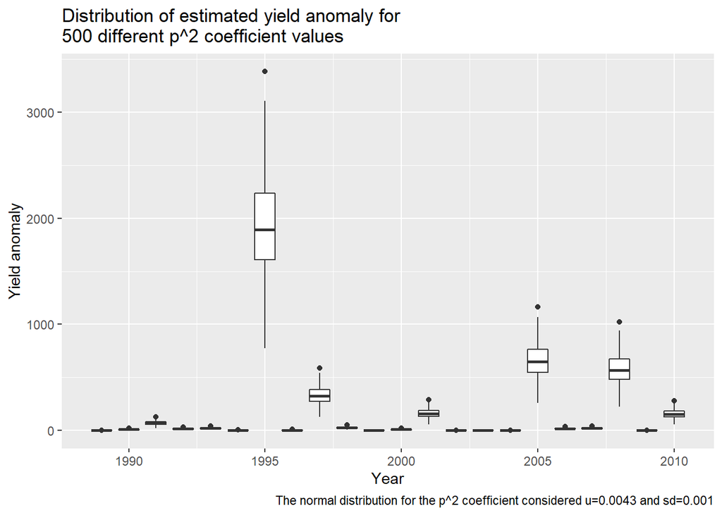

```r
# plot
ggplot(anom_result, aes(year,yield, group=year)) +
  geom_boxplot() +
  labs(title= "Distribution of estimated yield anomaly for\n500 different p^2 coefficient values",
       caption = "The normal distribution for the p^2 coefficient considered u=0.0043 and sd=0.001",
       y="Yield anomaly",
       x="Year")
```

If we omit the outlier years (1995, 2005, 2008), we confirm the distortion they caused, and other years 1997, 2001, and 2010 show importance in terms of squared precipitation. Still, the variability is pretty high.

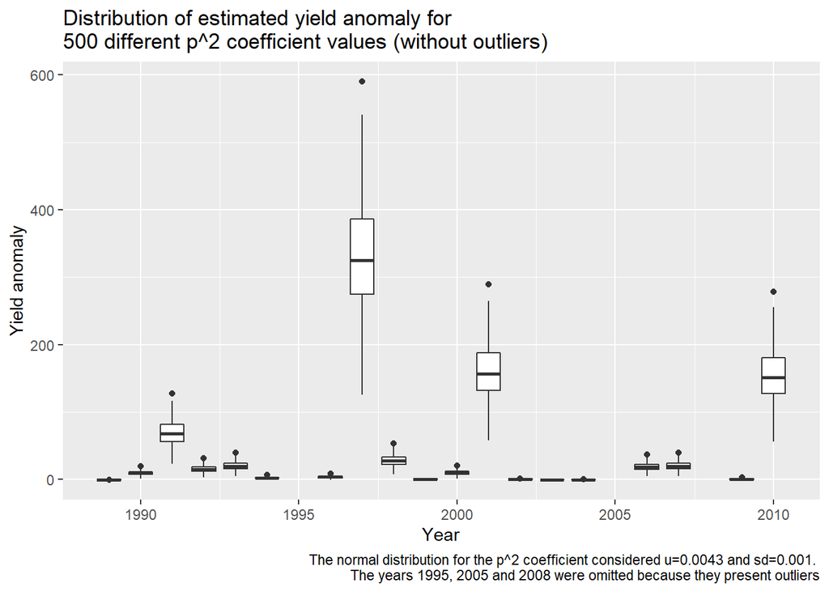

```r
# filter outlier years
anom_result_no_out <- anom_result %>%
  filter(year != 1995, year != 2005, year != 2008)

# plot
ggplot(anom_result_no_out, aes(year,yield, group=year)) +
  geom_boxplot() +
  labs(title= "Distribution of estimated yield anomaly for\n500 different p^2 coefficient values (without outliers)",
       caption = "The normal distribution for the p^2 coefficient considered u=0.0043 and sd=0.001.
       The years 1995, 2005 and 2008 were omitted because they present outliers",
       y="Yield anomaly",
       x="Year")
```

### 3. Net present value

Before running the NPV for the almond profits, we need to estimate the almond production. For this purpose, we will take our yield anomaly (tons/acre) and sum the annual average yield (tons/acre) of almonds. In this case, the yearly average is 1 ton/acre. Also, all negative values of this sum are replaced with zero.

```r
# Net present value

# We calculate the average production+anomaly (maybe this can be part of the model)

average_yield=1 #tons per year

yield_result <- anom_result %>%
  mutate(true_yield=average_yield+yield,#yield=anomaly; true_yield=average+anomaly
         true_yield_replace=ifelse(true_yield < 0, 0, true_yield))

#we assume 1 acres
npv_almond <- almond_profit(almond=yield_result$true_yield_replace,
                            year=yield_result$year)
```

Considering a discount rate of 0.12, one acre and bringing all the values back to 1989, we observe the profits may have a cyclical behavior except for the 1995 where the precipitations are too extreme. As expected, we also face a lot of profit uncertainty in the year 1995. Thus, it is not recommended to make risky strategies in those years unless the company has a good plan B.

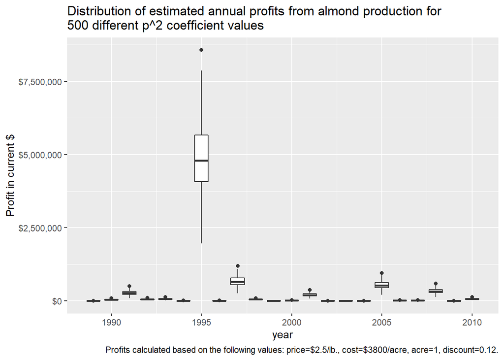

```r
ggplot(npv_almond , aes(year, netpre, group=year))+
  geom_boxplot()+labs(title= "Distribution of estimated annual profits from almond production for\n500 different p^2 coefficient values",
                      caption = "Profits calculated based on the following values: price=$2.5/lb., cost=$3800/acre, acre=1, discount=0.12.",
                      y="Profit in current $",
                      x="year")+
  scale_y_continuous(labels=dollar_format())
```

If we omit the year 1995, we observe the NPV have a cyclical behavior linked to precipitations. Each 4-8 years, we can expect to have outstanding production, and net profits.

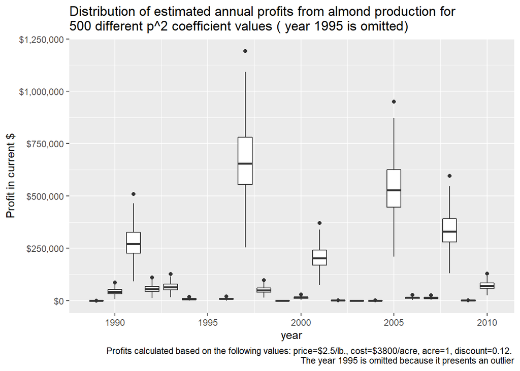

```r
npv_almond_no_out <- npv_almond %>%
  filter(year != 1995)

# plot
ggplot(npv_almond_no_out , aes(year, netpre, group=year))+
  geom_boxplot()+labs(title= "Distribution of estimated annual profits from almond production for\n500 different p^2 coefficient values ( year 1995 is omitted)",
                      caption = "Profits calculated based on the following values: price=$2.5/lb., cost=$3800/acre, acre=1, discount=0.12.
                      The year 1995 is omitted because it presents an outlier",
                      y="Profit in current $",
                      x="year")+
  scale_y_continuous(labels=dollar_format())
```

### References

- Lobell, D., Field C., Cahill, K., & Bonfils, C. (2006). Impacts of future climate change on California perennial crop yields: Model projections with climate and crop uncertainties. *Agricultural and Forest Meteorology* 141, 208–218.

### Appendix 1: Almond yield anomalies function

```r
# Function to calculate the yield anomaly for almonds
# ESM 232
# Function developed by Kat Leigh, David Segan, Alex Milward and Mauricio Collado
######################################


# 1. We upload the packages
library(tidyverse)
library(here)

# 2. Dataframe format
#
#' Dataframe requires the following columns: date, day, month, year,
#' daily precipitations,and daily minimum temperature
#' The columns must be named exactly: day, month, year, tmin_c, and precip
#' The variable units are Celsius (tmin_c) and mm (precip)
#
# Read in data
climate_df <- read.delim(here('clim.txt'), sep = " ")

# 3. Model for yield anomaly for almonds
#
# Function uses a polynomic model with 2 climate variables
# to estimate the yield anomaly for almonds (tons acre)
#' @param climate_df name of the dataset with the climate variables over time
#' @param var1_mon month for minimum temperature Default is 2
#' @param var2_mon month for precipitation Default is 1
#' @param coef_t1 coefficient for min temperatue Default is -0.015
#' @param coef_t2 coefficient for squared min temperatue Default is -0.0046
#' @param coef_p1 coefficient for precipitation Default is -0.07
#' @param coef_p2 coefficient for squared precipitation Default is 0.0043
#' @param intercept Intercept of the relationship Default 0.28
#' @references
#' Lobell (2006).

almond_anomaly = function(climate_df, #dataframe
                          var1_mon=2, #month for variable 1
                          var2_mon=1, #month for variable 1
                          coef_t1=-0.015, #coeficient for tmin
                          coef_t2=-0.0046, #coeficient for squared tmin
                          coef_p1=-0.07, #coeficient for precip
                          coef_p2=0.0043, #coeficient for squared precip
                          intercept=0.28){ #contant

# We filter the dataframe for monthly average precipitation and minimun temp

filt_clim_df <- climate_df %>%
   group_by(year, month) %>% #we group by month and year
   summarize(mean_tmin = mean(tmin_c), #mean t_min within each month
             sum_p = sum(precip)) %>%  #sum of precip within each month
   filter(month %in% c(var1_mon,var2_mon)) # we keep the relevant months

# first and last year
firstyear=min(filt_clim_df$year) # first year of filtered dataset
lastyear=max(filt_clim_df$year) # last year of filtered dataset

# We filter the dataframe for the average minimum temperatures for February of each year
clim_var1_df <- filt_clim_df %>%
   filter(month == var1_mon) %>% #filter month for tmin
   select(mean_tmin)

# We filter the dataframe for total precipitation for January of each year
clim_var2_df <- filt_clim_df %>%
   filter(month == var2_mon) %>% #filter month for precip
   select(sum_p)

# We process the information and save it into a dataframe
yield_anom <- data.frame(year= seq(firstyear, lastyear, by = 1), # year
                         yield=coef_t1*clim_var1_df$mean_tmin # estimation
                            + coef_t2*(clim_var1_df$mean_tmin^2)
                            + coef_p1*clim_var2_df$sum_p
                            + coef_p2*(clim_var2_df$sum_p^2)
                            + intercept)

return(yield_anom) # result as dataset

}

######################################
# The end
```

### Appendix 2: Compute net present value function

```r
#' Function to compute the net present value
#' ESM 232
#' Author: Naomi Tague
######################################

#' compute net present value
#' @param value/cost ($)
#' @param time in the future that cost/value occurs (years)
#' @param discount rate. The default value is 0.12
#' @return value in $


compute_NPV = function(value, time, discount=0.12) {
  result = value / (1 + discount)**time
  return(result)
}
```

### Appendix 2: Net profits for almonds

```r
# Function to calculate profits from almonds
# ESM 232
# Authors: Kat Leigh, David Segan, Alex Milward and Mauricio Collado
######################################

#' @param  almond (ton/acre)
#' @param  year
#' @param  price ($/lb), the default value is $ 2.5/lb
#' @param  cost (cost/acre), the default value is $ 3800/acre
#' @param acre land parameter, the default value is 1
#' @param discount rate, the default value is 0.12
#' @return data frame with estimate of profit
almond_profit = function(almond, year, price=2.5, cost=3800, acre=1, discount=0.12) {

  price_ton=price*2000 # we transform price/lb to price/ton

  # make sure values are reasonable
  if (length(almond) < 1)
    return(NA)

  # yield cannot be negative
  # if (min(almond) < 0)
  # return(NA)

  # generate a unique identifier or scenario number
  scen = seq(from=1, to=length(almond))
  #create dataframe with columns scenario, yield and years
  yearprofit = data.frame(scen=scen,
                          almond=almond,
                          year=year)

  # We calculate the net profits price*production - cost per acre
  yearprofit$net =  (yearprofit$almond*(price_ton)*acre)-(cost*acre)

  # remember to normalize the year to start year e.g the first year
  yearprofit= yearprofit %>%
    mutate(netpre = compute_NPV(value=net, time=year-year[1], discount=discount ))

  return(yearprofit)
}
```